# Hands-On Programming with R Notes

Alan Arnholt

2016-02-15

The outer product $\boldsymbol{u} \otimes \boldsymbol{v}^T$ is equivalent to a matrix multiplication $\boldsymbol{u}\boldsymbol{v}^T$, provided $\boldsymbol{u}$ is represented as a $m \times 1$ column vector and $\boldsymbol{v}$ as a $n \times$ column vector. See [Wikipedia](https://en.wikipedia.org/wiki/Outer_product) for more details.

```r
u <- 1:4
v <- 1:3
uOUTERv <- u %o% v
uOUTERv
```

```
     [,1] [,2] [,3]
[1,]    1    2    3
[2,]    2    4    6
[3,]    3    6    9
[4,]    4    8   12
```

The inner product $\langle \boldsymbol{u}, \boldsymbol{v}\rangle = \boldsymbol{u}^T\boldsymbol{v}$ provided $m=n$ yields a scalar (or $1 \times 1$ matrix).

```r
u <- 1:6
v <- 1:6
u %*% v
```

```
     [,1]
[1,]   91
```

```r
sum(u^2)
```

```
[1] 91
```

## Functions

When working with nested functions, operations all start with the innermost operation and work to the outermost.

```r
set.seed(3)
round(mean(sample(1:10)))
```

```
[1] 6
```

## Sample with Replacement

```r
set.seed(4)
sample(1:6, size = 2, replace = FALSE) # replace = FALSE is the default
```

```
[1] 4 1
```

```r
sample(1:6, size = 2, replace = TRUE)
```

```
[1] 2 2
```

## Writing Your Own Functions

```r
roll <- function(){
  die <- 1:6
  dice <- sample(die, size = 2, replace = TRUE)
  sum(dice)
}
roll()
```

```
[1] 7
```

```r
roll()
```

```
[1] 11
```

```r
roll()
```

```
[1] 7
```

```r
roll2 <- function(bones){
  dice <- sample(bones, size = 2, replace = TRUE)
  sum(dice)
}
roll2(bones = 1:4)
```

```
[1] 6
```

```r
roll2(bones = 1:6)
```

```
[1] 7
```

```r
roll2(bones = 1:10)
```

```
[1] 10
```

## Supplying Default Arguments

```r
roll2 <- function(bones = 1:6){
  dice <- sample(bones, size = 2, replace = TRUE)
  sum(dice)
}
roll2()
```

```
[1] 10
```

## Chapter 2

### `ggplot2`

#### Scaterplots

```r
x <- seq(from = -1, to = 1, by  = 0.2)
x
```

```
 [1] -1.0 -0.8 -0.6 -0.4 -0.2  0.0  0.2  0.4  0.6  0.8  1.0
```

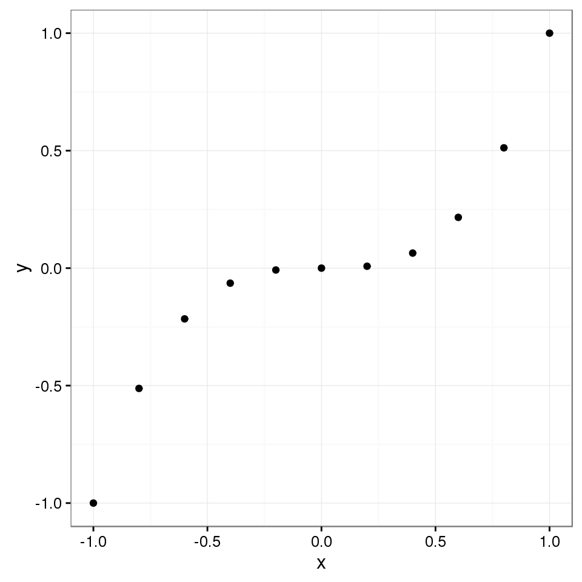

```r
y <- x^3
DF <- data.frame(x = x, y = y)
library(ggplot2)
ggplot(data = DF, aes(x = x, y = y)) +
  geom_point() +
  theme_bw()
```

#### Histograms

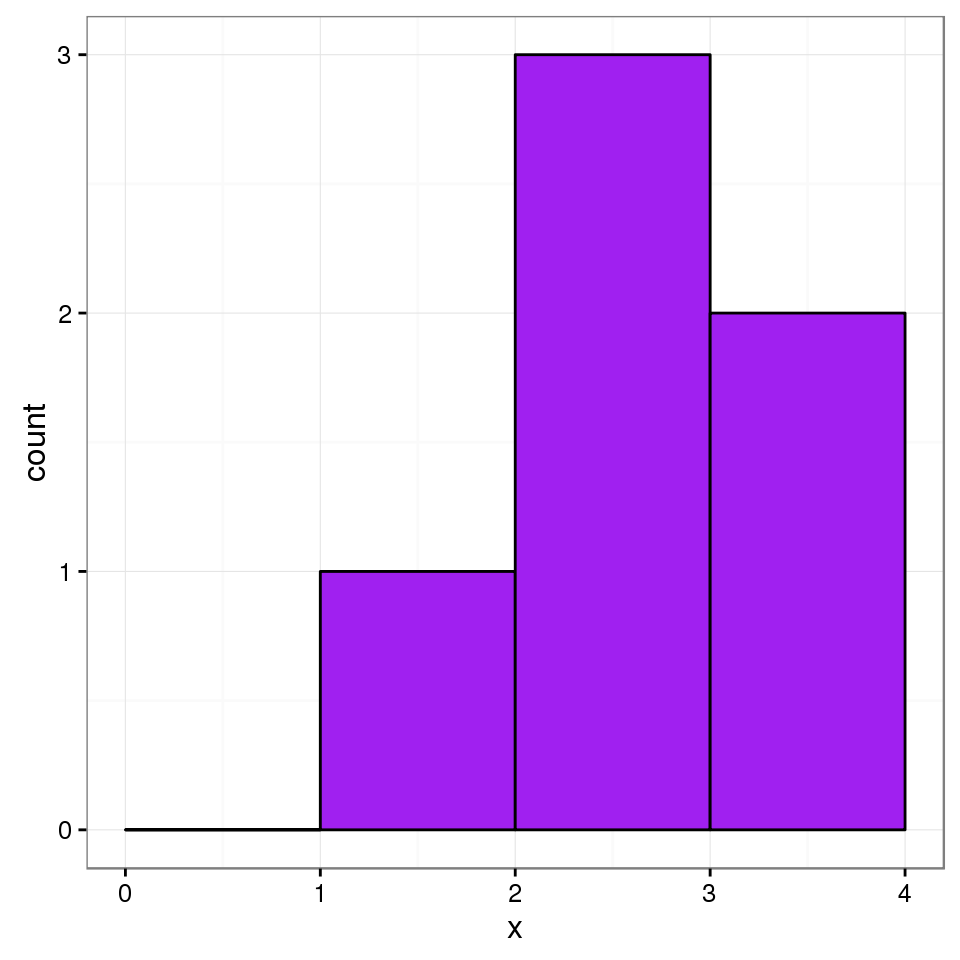

```r
x <- c(1, 2, 2, 2, 3, 3)
DF2 <- data.frame(x = x)
ggplot(data = DF2, aes(x = x)) +
  geom_histogram(binwidth = 1, fill = "purple", color = "black") +
  theme_bw()
```

### `ggvis`

#### Scatterplots

```r
library(ggvis)
DF %>%
  ggvis(x = ~x, y = ~y) %>%
  layer_points()
```

#### Histograms

```r
DF2 %>%
  ggvis(x = ~x, fill := "green") %>%
  layer_histograms(width = 1)
```

## Exercise

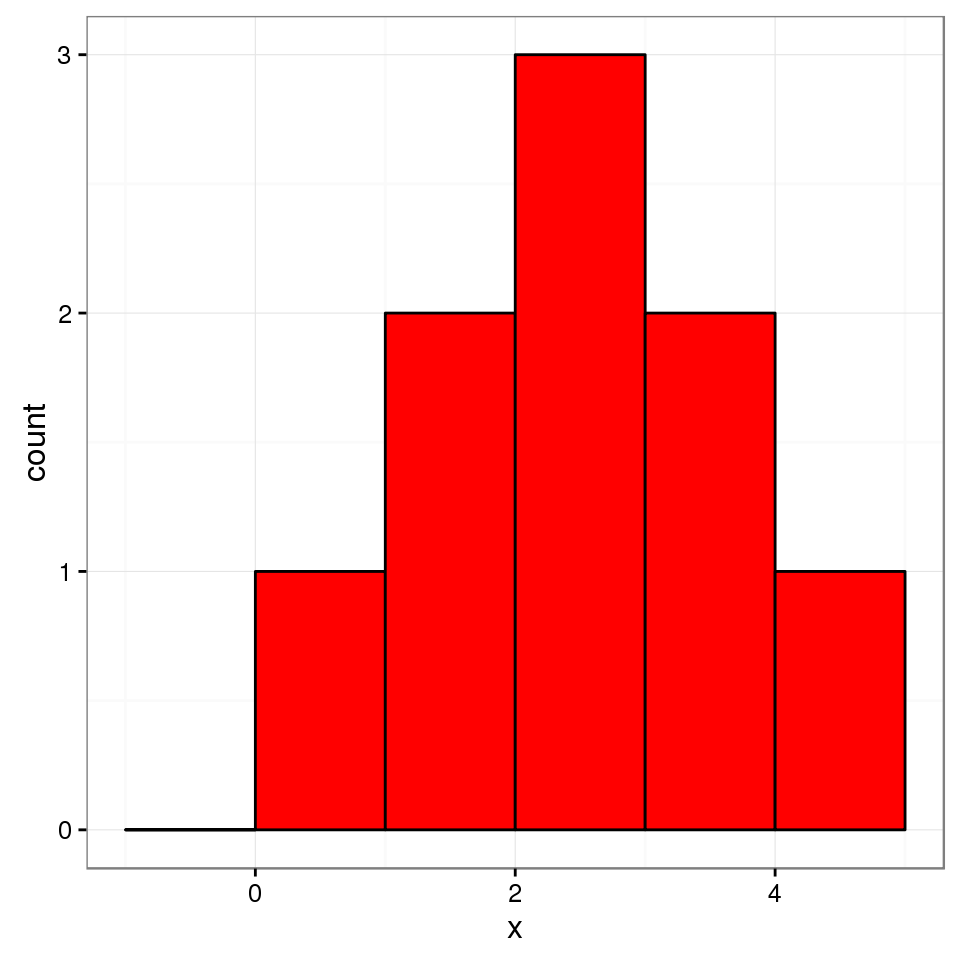

```r
x3 <- c(0, 1, 1, 2, 2, 2, 3, 3, 4)
DF3 <- data.frame(x = x3)
# Use ggplot2 first
ggplot(data = DF3, aes(x = x)) +
  geom_histogram(binwidth = 1, fill = "red", color = "black") +
  theme_bw()
```

```r
# Use ggvis next
DF3 %>%
  ggvis(x = ~x, fill := "lightblue") %>%
  layer_histograms(width = 1)
```

### Using `replicate()`

```r
replicate(10, 3 + 3.24)
```

```
 [1] 6.24 6.24 6.24 6.24 6.24 6.24 6.24 6.24 6.24 6.24
```

```r
replicate(10, roll())
```

```
 [1]  7  9  9  8  6 10  9  7  4  8
```

```r
rolls <- replicate(10000, roll())
STR <- system.time(replicate(10000, roll()))
STR
```

```
   user  system elapsed
  0.145   0.000   0.146
```

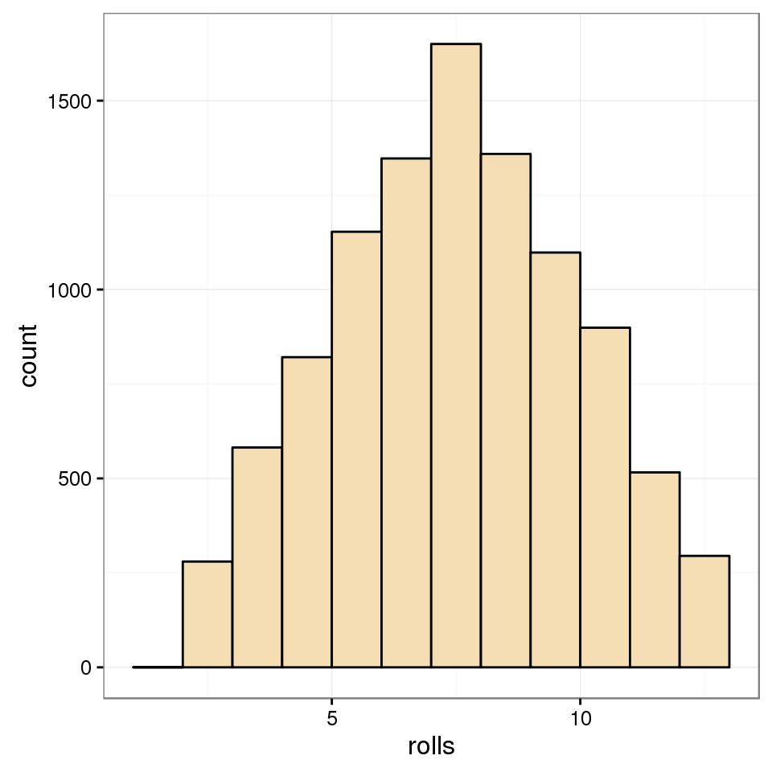

```r
DF4 <- data.frame(rolls = rolls)
# Use ggplot2 first
ggplot(data = DF4, aes(x = rolls)) +
  geom_histogram(binwidth = 1, fill = "wheat", color = "black") +
  theme_bw()
```

```r
# Use ggvis next
DF4 %>%
  ggvis(x = ~rolls, fill := "salmon") %>%
  layer_histograms(width = 1)
```

### Another Approach to `replicate()`

```r
N <- 10000
rolls <- numeric(N)
for(i in 1:N){
  rolls[i] <- roll()
}
# Make this into a function
FL <- function(N = 10000){
  rolls <- numeric(N)
  for(i in 1:N){
  rolls[i] <- roll()
}
}
STL <- system.time(FL())
STL
```

```
   user  system elapsed
  0.098   0.000   0.098
```

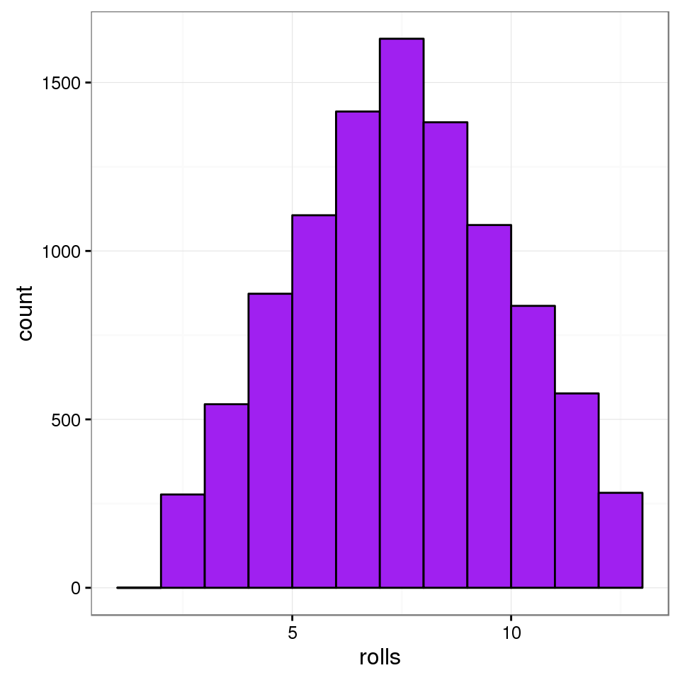

```r
DF5 <- data.frame(rolls = rolls)
# Use ggplot2 first
ggplot(data = DF5, aes(x = rolls)) +
  geom_histogram(binwidth = 1, fill = "purple", color = "black") +
  theme_bw()
```

```r
# Use ggvis next
DF5 %>%
  ggvis(x = ~rolls, fill := "indianred") %>%
  layer_histograms(width = 1)
```

## Exercise

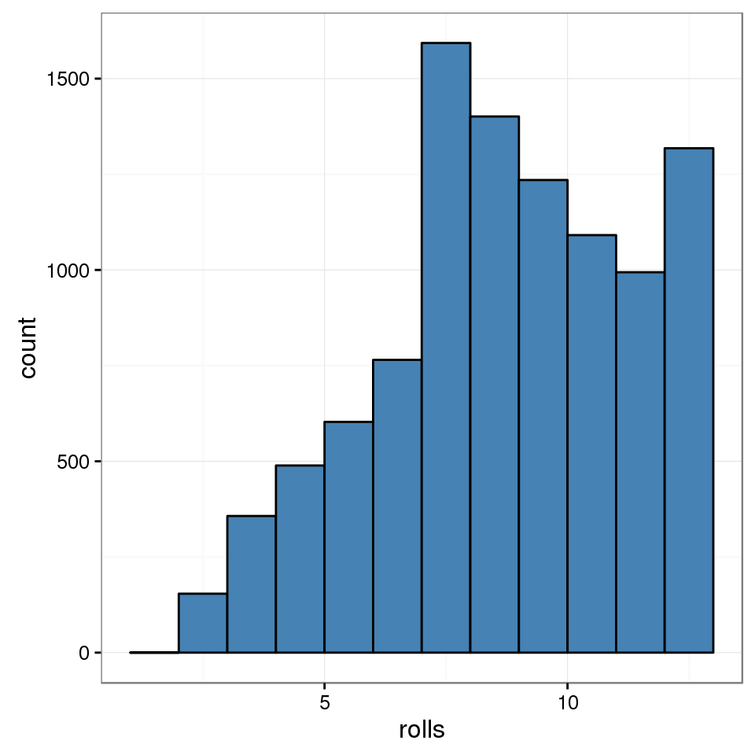

```r
roll <- function(){
  die <- 1:6
  dice <- sample(die, size = 2, replace = TRUE,
                 prob = c(1/8, 1/8, 1/8, 1/8, 1/8, 3/8))
  sum(dice)
}
rolls <- replicate(10000, roll())
DF6 <- data.frame(rolls = rolls)
# Use ggplot2 first
ggplot(data = DF6, aes(x = rolls)) +
  geom_histogram(binwidth = 1, fill = "steelblue", color = "black") +
  theme_bw()
```

```r
# Use ggvis next
DF6 %>%
  ggvis(x = ~rolls, fill := "magenta") %>%
  layer_histograms(width = 1)
```

## Uber Die

```r
roll <- function(dietype = 1:6, probvalues = rep(1/length(dietype), length(dietype))){
  if(sum(probvalues) != 1)
    stop("'probvalues' must add to one")
  dice <- sample(dietype, size = 2, replace = TRUE, prob = probvalues)
  sum(dice)
}
roll(dietype = c(1,3,5,7))
```

```
[1] 8
```

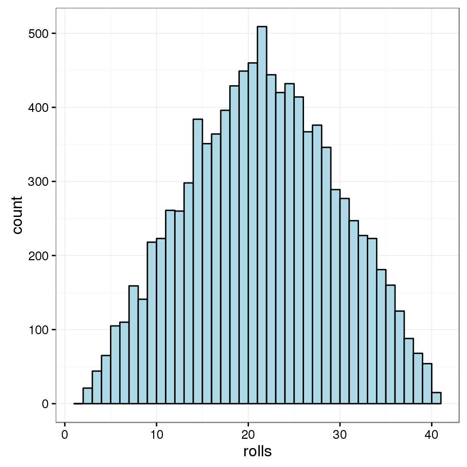

```r
rolls <- replicate(10000, roll(dietype = 1:20))
DF7 <- data.frame(rolls = rolls)
# Use ggplot2 first
ggplot(data = DF7, aes(x = rolls)) +
  geom_histogram(binwidth = 1, fill = "lightblue", color = "black") +
  theme_bw()
```

```r
# Use ggvis next
DF7 %>%
  ggvis(x = ~rolls, fill := "orange") %>%
  layer_histograms(width = 1)
```

# Chapter 3 Notes

## Exercise

Can you spot the difference between a character string and a number? Here’s a test: Which of these are character strings and which are numbers? 1, “1”, “one”.

```r
x <- 1
y <- "1"
z <- "one"
typeof(1)
```

```
[1] "double"
```

```r
typeof(x)
```

```
[1] "double"
```

```r
typeof("1")
```

```
[1] "character"
```

```r
typeof(y)
```

```
[1] "character"
```

```r
typeof("one")
```

```
[1] "character"
```

```r
typeof(z)
```

```
[1] "character"
```

## Exercise

Create an atomic vector that stores just the face names of the cards in a royal flush (ace through ten all one suit), for example, the ace of spades, king of spades, queen of spades, jack of spades, and ten of spades. The face name of the ace of spades would be “ace”, and “spades” is the suit. Which type of vector will you use to save the names?

```r
FaceNames <- c("ace", "king", "queen", "jack", "ten")
FaceNames
```

```
[1] "ace"   "king"  "queen" "jack"  "ten"
```

```r
typeof(FaceNames)
```

```
[1] "character"
```

## Exercise

Create the following matrix, which stores the name and suit of every card in a royal flush.

```
     [,1]    [,2]
[1,] "ace"   "spaces"
[2,] "king"  "spaces"
[3,] "queen" "spaces"
[4,] "jack"  "spaces"
[5,] "ten"   "spaces"
```

```r
hand1 <- c("ace", "king", "queen", "jack", "ten", rep("spades", 5))
matrix(hand1, ncol = 2)
```

```
     [,1]    [,2]
[1,] "ace"   "spades"
[2,] "king"  "spades"
[3,] "queen" "spades"
[4,] "jack"  "spades"
[5,] "ten"   "spades"
```

```r
matrix(hand1, nrow = 5)
```

```
     [,1]    [,2]
[1,] "ace"   "spades"
[2,] "king"  "spades"
[3,] "queen" "spades"
[4,] "jack"  "spades"
[5,] "ten"   "spades"
```

```r
dim(hand1) <- c(5, 2)
hand1
```

```
     [,1]    [,2]
[1,] "ace"   "spades"
[2,] "king"  "spades"
[3,] "queen" "spades"
[4,] "jack"  "spades"
[5,] "ten"   "spades"
```

**Note:** R matrices are column major.

## Dates and Times

```r
now <- Sys.time()
now
```

```
[1] "2016-02-15 14:51:51 EST"
```

```r
typeof(now)
```

```
[1] "double"
```

```r
class(now)
```

```
[1] "POSIXct" "POSIXt"
```

```r
SEC <- unclass(now)
SEC
```

```
[1] 1455565912
```

The number stored in `SEC` represents the number of seconds that have passed between the time and 12:00 AM January 1st 1970 (in the Universal Time Coordinated (UTC) zone).

## Factors

```r
gender <- factor(c("male", "female", "female", "male"))
typeof(gender)
```

```
[1] "integer"
```

```r
attributes(gender)
```

```
$levels
[1] "female" "male"

$class
[1] "factor"
```

```r
unclass(gender)
```

```
[1] 2 1 1 2
attr(,"levels")
[1] "female" "male"
```

## Exercise

Many card games assign a numerical value to each card. For example, in blackjack, each face card is worth 10 points, each number card is worth between 2 and 10 points, and each ace is worth 1 or 11 points, depending on the final score. Make a virtual card by combining “ace”, “heart”, and 1 into a vector. What type of atomic vector will result? **Character** Check if you are right.

```r
card <- c("ace", "heart", 1)
typeof(card)
```

```
[1] "character"
```

## Exercise

Use a list to store a single playing card, like the ace of hearts, which has a point value of one. The list should save the face of the card, the suit, and the point value in separate elements.

```r
card <-  list(face = "ace", suit = "hearts", value = 1)
card
```

```
$face
[1] "ace"

$suit
[1] "hearts"

$value
[1] 1
```

## Data Frames

```r
df <- data.frame(face = c("ace", "two", "six"), suit = c("clubs", "clubs", "clubs"), value = c(1, 2, 3))
df
```

```
  face  suit value
1  ace clubs     1
2  two clubs     2
3  six clubs     3
```

```r
typeof(df)
```

```
[1] "list"
```

```r
class(df)
```

```
[1] "data.frame"
```

```r
str(df)
```

```
'data.frame':   3 obs. of  3 variables:
 $ face : Factor w/ 3 levels "ace","six","two": 1 3 2
 $ suit : Factor w/ 1 level "clubs": 1 1 1
 $ value: num  1 2 3
```

```r
df2 <- data.frame(face = c("ace", "two", "six"), suit = c("clubs", "clubs", "clubs"), value = c(1, 2, 3), stringsAsFactors = FALSE)
df2
```

```
  face  suit value
1  ace clubs     1
2  two clubs     2
3  six clubs     3
```

```r
typeof(df2)
```

```
[1] "list"
```

```r
class(df2)
```

```
[1] "data.frame"
```

```r
str(df2)
```

```
'data.frame':   3 obs. of  3 variables:
 $ face : chr  "ace" "two" "six"
 $ suit : chr  "clubs" "clubs" "clubs"
 $ value: num  1 2 3
```

**Creating a deck of cards with less typing**

```r
Face <- c("king", "queen","jack", "ten","nine","eight","seven","six","five","four","three","two","ace")
Suit <- c("spades","clubs", "diamonds", "hearts")
Value = 13:1
deck <- data.frame(face = rep(Face, 4), suit = rep(Suit, each = 13), value = rep(Value, 4), stringsAsFactors = FALSE)
library(DT)
datatable(deck)
```

|  | face | suit | value |
| --- | --- | --- | --- |
| 1 | king | spades | 13 |
| 2 | queen | spades | 12 |
| 3 | jack | spades | 11 |
| 4 | ten | spades | 10 |
| 5 | nine | spades | 9 |
| 6 | eight | spades | 8 |
| 7 | seven | spades | 7 |
| 8 | six | spades | 6 |
| 9 | five | spades | 5 |
| 10 | four | spades | 4 |

[output cut: 42 more lines]

## Reading a file from a secure web site using `readr::read_csv()` and `repmis::source_data()`

**Note:** `read.csv()` will not read from `https` (Hypertext Transfer Protocol Secure) web sites.

```r
site <- "https://gist.githubusercontent.com/garrettgman/9629323/raw/ee5dfc039fd581cb467cc69c226ea2524913c3d8/deck.csv"
deck2 <- readr::read_csv(site)
head(deck2)
```

```
Source: local data frame [6 x 3]

   face   suit value
  (chr)  (chr) (int)
1  king spades    13
2 queen spades    12
3  jack spades    11
4   ten spades    10
5  nine spades     9
6 eight spades     8
```

```r
deck1 <- repmis::source_data(url = site, sep = ",", header = TRUE)
```

```
Downloading data from: https://gist.githubusercontent.com/garrettgman/9629323/raw/ee5dfc039fd581cb467cc69c226ea2524913c3d8/deck.csv
```

```
SHA-1 hash of the downloaded data file is:
a1cdb425b6cd2b030f9538257b7c2a61c6e6c8b1
```

```r
datatable(deck1)
```

|  | face | suit | value |
| --- | --- | --- | --- |
| 1 | king | spades | 13 |
| 2 | queen | spades | 12 |
| 3 | jack | spades | 11 |
| 4 | ten | spades | 10 |
| 5 | nine | spades | 9 |
| 6 | eight | spades | 8 |
| 7 | seven | spades | 7 |
| 8 | six | spades | 6 |
| 9 | five | spades | 5 |
| 10 | four | spades | 4 |

[output cut: 42 more lines]

## Saving Data

```r
write.csv(deck1, file = "cards.csv", row.names = FALSE)
```

## Downloading any file secure or not

We download the `deck.csv` file from the supplied GitHub url stored in the character string `site` and store the downloaded file as `DFcards.csv` in the same directory as the current document.

```r
download.file(url = site, destfile = "./DFcards.csv", method = "curl")
list.files()
```

```
 [1] "cards.csv"
 [2] "Chapter7.html"
 [3] "Chapter7.Rmd"
 [4] "Chapters1and2.html"
 [5] "Chapters1and2.Rmd"
 [6] "Chapters3and4.html"
 [7] "Chapters3and4.Rmd"
 [8] "Chapters5and6.html"
 [9] "Chapters5and6.Rmd"
[10] "CopyOfHandsOnProgrammingNotesHead.Rmd"
[11] "DFcards.csv"
[12] "FMhopwr_files"
[13] "FMhopwr.Rmd"
[14] "PackageBuilding.html"
[15] "PackageBuilding.Rmd"
[16] "PackagesUsed.bib"
[17] "PNG"
```

# Chapter 4 Notes

## Selecting Values

```r
head(deck)
```

```
   face   suit value
1  king spades    13
2 queen spades    12
3  jack spades    11
4   ten spades    10
5  nine spades     9
6 eight spades     8
```

```r
deck[1, 1]
```

```
[1] "king"
```

```r
deck[1, 1:3]
```

```
  face   suit value
1 king spades    13
```

```r
deck[1:2, 1]  # returns a single column
```

```
[1] "king"  "queen"
```

```r
deck[1:2, 1, drop = FALSE] # returns a data frame
```

```
   face
1  king
2 queen
```

```r
deck[-(2:52), 1:3] # everything except rows 2-52 for cols 1-3
```

```
  face   suit value
1 king spades    13
```

### Blank Spaces

You can use a blank space to tell `R` to extract *every* value in a dimension.

```r
deck[1, ]  # same as deck[1, 1:3]
```

```
  face   suit value
1 king spades    13
```

### Logical Values

```r
set.seed(4)
sims <- 10000
xbar <- numeric(sims)
for(i in 1:sims){
  xbar[i] <- mean(runif(50, 0, 10))
}
mean(xbar)
```

```
[1] 4.997238
```

```r
sd(xbar)
```

```
[1] 0.4113463
```

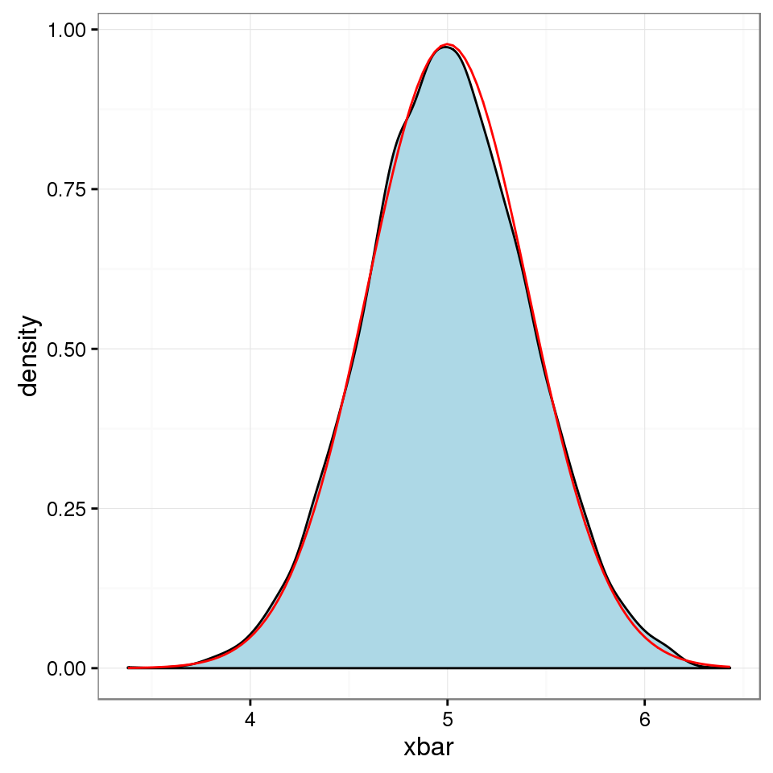

```r
library(ggplot2)
DF <- data.frame(xbar = xbar)
ggplot(data = DF, aes(x = xbar)) +
  geom_density(fill = "lightblue") +
  stat_function(fun = dnorm, args = list(mean = 5, sd = ((10)/sqrt(12))/sqrt(50)), color = "red") +
  theme_bw()
```

What percent of the values in `xbar` are between $5 - (10/\sqrt{12})/(\sqrt{50}) = 4.5917517$ and $5 + (10/\sqrt{12})/(\sqrt{50}) = 5.4082483$?

```r
LOG <- xbar >= (5 - ((10)/sqrt(12))/sqrt(50)) & xbar <= (5 + ((10)/sqrt(12))/sqrt(50))
head(LOG, n = 10)
```

```
 [1] FALSE  TRUE  TRUE  TRUE  TRUE  TRUE  TRUE FALSE  TRUE  TRUE
```

```r
head(which(LOG == TRUE), n = 10)
```

```
 [1]  2  3  4  5  6  7  9 10 11 13
```

```r
length(xbar[LOG])
```

```
[1] 6808
```

```r
mean(LOG)
```

```
[1] 0.6808
```

```r
# Compare to Normal
pnorm(1) - pnorm(-1)
```

```
[1] 0.6826895
```

## Exercise

Use the preceding ideas to write a shuffle function. `shuffle()` should take a data frame and return a shuffled copy of the data frame.

```r
shuffle <- function(cards){
  index <- sample(dim(cards)[1], size = dim(cards)[1], replace = FALSE)
  cards[index, ]
}
deck2 <- shuffle(cards = deck)
deck2[1:5, ]
```

```
    face     suit value
43   ten   hearts    10
38   two diamonds     2
24 three    clubs     3
10  four   spades     4
23  four    clubs     4
```

## Dollar Signs and Double Brackets

```r
deck$value
```

```
 [1] 13 12 11 10  9  8  7  6  5  4  3  2  1 13 12 11 10  9  8  7  6  5  4
[24]  3  2  1 13 12 11 10  9  8  7  6  5  4  3  2  1 13 12 11 10  9  8  7
[47]  6  5  4  3  2  1
```

```r
mean(deck$value)
```

```
[1] 7
```

```r
LST <- list(numbers = c(1, 2, 3, 4, 5), logical = c(TRUE, FALSE, TRUE), strings = c("dog", "cat", "horse", "car"))
LST
```

```
$numbers
[1] 1 2 3 4 5

$logical
[1]  TRUE FALSE  TRUE

$strings
[1] "dog"   "cat"   "horse" "car"
```

Subsetting the first element:

```r
LST[1]             # a list
```

```
$numbers
[1] 1 2 3 4 5
```

```r
LST[[1]]           # values inside element
```

```
[1] 1 2 3 4 5
```

```r
LST$numbers        # values inside element
```

```
[1] 1 2 3 4 5
```

```r
LST[['numbers']]   # values inside element
```

```
[1] 1 2 3 4 5
```

If you subset a list with single-bracket notation, `R` will return a smaller list. If you subset a list with double-bracket notation, `R` will return the values inside the element subsetted of the list.

# Chapter 5

## Changing Values in Place

```r
vec <- c(0, 0, 0, 0, 0, 0)
vec
```

```
[1] 0 0 0 0 0 0
```

```r
vec[1]
```

```
[1] 0
```

```r
vec[1] <- 1000
vec
```

```
[1] 1000    0    0    0    0    0
```

```r
vec[c(1, 3, 5)] <- c(1, 1, 1)
vec
```

```
[1] 1 0 1 0 1 0
```

```r
vec[4:6] <- vec[4:6] + 1
vec
```

```
[1] 1 0 1 1 2 1
```

```r
vec[7] <- 0
vec
```

```
[1] 1 0 1 1 2 1 0
```

Start by creating a deck of cards:

```r
FACE <- c("king", "queen", "jack", "ten", "nine", "eight", "seven", "six", "five", "four", "three", "two", "ace")
SUIT <- c("spades", "clubs", "diamonds", "hearts")
VALUE <- 13:1
deck <- data.frame(face = rep(FACE, 4), suit = rep(SUIT, each = 13), value = rep(VALUE, times = 4))
library(DT)
datatable(deck)
```

|  | face | suit | value |
| --- | --- | --- | --- |
| 1 | king | spades | 13 |
| 2 | queen | spades | 12 |
| 3 | jack | spades | 11 |
| 4 | ten | spades | 10 |
| 5 | nine | spades | 9 |
| 6 | eight | spades | 8 |
| 7 | seven | spades | 7 |
| 8 | six | spades | 6 |
| 9 | five | spades | 5 |
| 10 | four | spades | 4 |

[output cut: 42 more lines]

### Add a Variable

```r
deck2 <- deck
deck2$new <- 1:52
datatable(deck2)
```

|  | face | suit | value | new |
| --- | --- | --- | --- | --- |
| 1 | king | spades | 13 | 1 |
| 2 | queen | spades | 12 | 2 |
| 3 | jack | spades | 11 | 3 |
| 4 | ten | spades | 10 | 4 |
| 5 | nine | spades | 9 | 5 |
| 6 | eight | spades | 8 | 6 |
| 7 | seven | spades | 7 | 7 |
| 8 | six | spades | 6 | 8 |
| 9 | five | spades | 5 | 9 |
| 10 | four | spades | 4 | 10 |

[output cut: 42 more lines]

```r
deck2$new <- NULL
head(deck2)
```

```
   face   suit value
1  king spades    13
2 queen spades    12
3  jack spades    11
4   ten spades    10
5  nine spades     9
6 eight spades     8
```

## Change Particular Values

```r
deck2[c(13, 26, 39, 52), ]
```

```
   face     suit value
13  ace   spades     1
26  ace    clubs     1
39  ace diamonds     1
52  ace   hearts     1
```

```r
deck2[c(13, 26, 39, 52), "value"]
```

```
[1] 1 1 1 1
```

```r
deck2[c(13, 26, 39, 52), 3]
```

```
[1] 1 1 1 1
```

```r
deck2$value[c(13, 26, 39, 52)]
```

```
[1] 1 1 1 1
```

```r
deck2$value[c(13, 26, 39, 52)] <- c(14, 14, 14, 14)
deck2$value[c(13, 26, 39, 52)]
```

```
[1] 14 14 14 14
```

```r
# OR
deck2$value[c(13, 26, 39, 52)] <- 14
deck2$value[c(13, 26, 39, 52)]
```

```
[1] 14 14 14 14
```

## Recall `shuffle()`

This function still need some work…

```r
shuffle <- function(cards) {
 random <- sample(1:52, size = 52)
 cards[random, ]
}
deck3 <- shuffle(deck)
datatable(deck3)
```

|  | face | suit | value |
| --- | --- | --- | --- |
| 22 | five | clubs | 5 |
| 46 | seven | hearts | 7 |
| 48 | five | hearts | 5 |
| 3 | jack | spades | 11 |
| 26 | ace | clubs | 1 |
| 42 | jack | hearts | 11 |
| 50 | three | hearts | 3 |
| 21 | six | clubs | 6 |
| 43 | ten | hearts | 10 |
| 20 | seven | clubs | 7 |

[output cut: 42 more lines]

## Logical Operators

```r
1 > 2
```

```
[1] FALSE
```

```r
1 > c(0, 1, 2)
```

```
[1]  TRUE FALSE FALSE
```

```r
c(1, 2, 3) == c(3, 2, 1)
```

```
[1] FALSE  TRUE FALSE
```

```r
1 %in% c(3, 4, 5)
```

```
[1] FALSE
```

```r
c(1, 2) %in% c(3, 4, 5)
```

```
[1] FALSE FALSE
```

```r
c(1, 2, 3) %in% c(3, 4, 5)
```

```
[1] FALSE FALSE  TRUE
```

```r
c(1, 2, 3, 4) %in% c(3, 4, 5)
```

```
[1] FALSE FALSE  TRUE  TRUE
```

## Exercise

Extract the face column of `deck2` and test whether each value is equal to ace. As a challenge, use `R` to quickly count how many cards are equal to `ace`.

```r
sum(deck2$face == "ace")
```

```
[1] 4
```

```r
deck3$face == "ace"
```

```
 [1] FALSE FALSE FALSE FALSE  TRUE FALSE FALSE FALSE FALSE FALSE FALSE
[12] FALSE FALSE FALSE FALSE FALSE FALSE FALSE FALSE FALSE FALSE FALSE
[23] FALSE FALSE FALSE FALSE FALSE FALSE FALSE FALSE FALSE FALSE FALSE
[34] FALSE FALSE FALSE FALSE FALSE FALSE  TRUE FALSE  TRUE FALSE FALSE
[45] FALSE FALSE FALSE FALSE FALSE  TRUE FALSE FALSE
```

Change the value of `ace` to 14

```r
deck3$value[deck3$face == "ace"] <- 14
datatable(deck3)
```

|  | face | suit | value |
| --- | --- | --- | --- |
| 22 | five | clubs | 5 |
| 46 | seven | hearts | 7 |
| 48 | five | hearts | 5 |
| 3 | jack | spades | 11 |
| 26 | ace | clubs | 14 |
| 42 | jack | hearts | 11 |
| 50 | three | hearts | 3 |
| 21 | six | clubs | 6 |
| 43 | ten | hearts | 10 |
| 20 | seven | clubs | 7 |

[output cut: 42 more lines]

```r
deck4 <- deck
```

## Exercise

Assign a value of 1 to every card in `deck4` that has a suit of hearts.

```r
deck4$value[deck4$suit == "hearts"] <- 1
deck4$value[deck4$suit == "hearts"]
```

```
 [1] 1 1 1 1 1 1 1 1 1 1 1 1 1
```

```r
datatable(deck4)
```

|  | face | suit | value |
| --- | --- | --- | --- |
| 1 | king | spades | 13 |
| 2 | queen | spades | 12 |
| 3 | jack | spades | 11 |
| 4 | ten | spades | 10 |
| 5 | nine | spades | 9 |
| 6 | eight | spades | 8 |
| 7 | seven | spades | 7 |
| 8 | six | spades | 6 |
| 9 | five | spades | 5 |
| 10 | four | spades | 4 |

[output cut: 42 more lines]

In hearts, the queen of spades has the most unusual value of all: she’s worth 13 points.

```r
deck4$value[deck4$suit == "spades" & deck4$face == "queen"] <- 13
deck4$value[deck4$suit == "spades" & deck4$face == "queen"]
```

```
[1] 13
```

```r
datatable(deck4)
```

|  | face | suit | value |
| --- | --- | --- | --- |
| 1 | king | spades | 13 |
| 2 | queen | spades | 13 |
| 3 | jack | spades | 11 |
| 4 | ten | spades | 10 |
| 5 | nine | spades | 9 |
| 6 | eight | spades | 8 |
| 7 | seven | spades | 7 |
| 8 | six | spades | 6 |
| 9 | five | spades | 5 |
| 10 | four | spades | 4 |

[output cut: 42 more lines]

## Exercise

```r
w <- c(-1, 0, 1)
x <- c(5, 15)
y <- "February"
z <- c("Monday", "Tuesday", "Friday")
w > 0
```

```
[1] FALSE FALSE  TRUE
```

```r
10 < x & x < 20
```

```
[1] FALSE  TRUE
```

```r
y == "February"
```

```
[1] TRUE
```

```r
all(z %in% c("Monday", "Tuesday", "Wednesday", "Thursday", "Friday", "Saturday", "Sunday"))
```

```
[1] TRUE
```

```r
deck5 <- deck
```

Change the value of all face cards to 10

```r
deck5$value[deck5$face %in% c("king", "queen", "jack")] <- 10
datatable(deck5)
```

|  | face | suit | value |
| --- | --- | --- | --- |
| 1 | king | spades | 10 |
| 2 | queen | spades | 10 |
| 3 | jack | spades | 10 |
| 4 | ten | spades | 10 |
| 5 | nine | spades | 9 |
| 6 | eight | spades | 8 |
| 7 | seven | spades | 7 |
| 8 | six | spades | 6 |
| 9 | five | spades | 5 |
| 10 | four | spades | 4 |

[output cut: 42 more lines]

## Missing Information

```r
1 + NA
```

```
[1] NA
```

```r
NA == 1
```

```
[1] NA
```

```r
c(NA, 1:50)
```

```
 [1] NA  1  2  3  4  5  6  7  8  9 10 11 12 13 14 15 16 17 18 19 20 21 22
[24] 23 24 25 26 27 28 29 30 31 32 33 34 35 36 37 38 39 40 41 42 43 44 45
[47] 46 47 48 49 50
```

```r
mean(c(NA, 1:50))
```

```
[1] NA
```

```r
mean(c(NA, 1:50), na.rm = TRUE)
```

```
[1] 25.5
```

```r
NA == NA
```

```
[1] NA
```

```r
c(1, 2, 3, NA) == NA
```

```
[1] NA NA NA NA
```

```r
is.na(NA)
```

```
[1] TRUE
```

```r
vec <- c(1, 2, 3, NA)
is.na(vec)
```

```
[1] FALSE FALSE FALSE  TRUE
```

```r
deck5$value[deck5$face == "ace"] <- NA
head(deck5, 13)
```

```
    face   suit value
1   king spades    10
2  queen spades    10
3   jack spades    10
4    ten spades    10
5   nine spades     9
6  eight spades     8
7  seven spades     7
8    six spades     6
9   five spades     5
10  four spades     4
11 three spades     3
12   two spades     2
13   ace spades    NA
```

# Environments

```r
library(pryr)
library(knitr)
parenvs(all = TRUE)
```

```
   label                            name
1  <environment: R_GlobalEnv>       ""
2  <environment: package:pryr>      "package:pryr"
3  <environment: package:DT>        "package:DT"
4  <environment: package:ggvis>     "package:ggvis"
5  <environment: package:ggplot2>   "package:ggplot2"
6  <environment: package:knitr>     "package:knitr"
7  <environment: package:stats>     "package:stats"
8  <environment: package:graphics>  "package:graphics"
9  <environment: package:grDevices> "package:grDevices"
10 <environment: package:utils>     "package:utils"
11 <environment: package:datasets>  "package:datasets"
12 <environment: package:methods>   "package:methods"
13 <environment: 0x16d6bb8>         "Autoloads"
14 <environment: base>              ""
15 <environment: R_EmptyEnv>        ""
```

```r
as.environment("package:knitr")
```

```
<environment: package:knitr>
attr(,"name")
[1] "package:knitr"
attr(,"path")
[1] "/home/faculty/arnholtat/R/x86_64-pc-linux-gnu-library/3.2/knitr"
```

```r
globalenv()
```

```
<environment: R_GlobalEnv>
```

```r
baseenv()
```

```
<environment: base>
```

```r
emptyenv()
```

```
<environment: R_EmptyEnv>
```

Next, you can look up an environment’s parent with `parent.env`:

```r
parent.env(globalenv())
```

```
<environment: package:pryr>
attr(,"name")
[1] "package:pryr"
attr(,"path")
[1] "/home/faculty/arnholtat/R/x86_64-pc-linux-gnu-library/3.2/pryr"
```

Notice that the empty environment is the only R environment without a parent:

```r
parent.env(emptyenv())
```

```
Error in parent.env(emptyenv()): the empty environment has no parent
```

You can view the objects saved in an environment with `ls` or `ls.str`. `ls` will return just the object names, but `ls.str` will display a little about each object’s structure:

```r
ls(emptyenv())
```

```
character(0)
```

```r
ls(globalenv())
```

```
 [1] "card"      "deck"      "deck1"     "deck2"     "deck3"
 [6] "deck4"     "deck5"     "df"        "DF"        "df2"
[11] "DF2"       "DF3"       "DF4"       "DF5"       "DF6"
[16] "DF7"       "Face"      "FACE"      "FaceNames" "FL"
[21] "gender"    "hand1"     "i"         "LOG"       "LST"
[26] "MAT"       "N"         "now"       "roll"      "roll2"
[31] "rolls"     "SEC"       "shuffle"   "sims"      "site"
[36] "STL"       "STR"       "Suit"      "SUIT"      "u"
[41] "uOUTERv"   "v"         "Value"     "VALUE"     "vec"
[46] "w"         "x"         "x3"        "xbar"      "y"
[51] "z"
```

You can use `R`’s `$` syntax to access an object in a specific environment. For example, you can access deck from the global environment:

```r
head(globalenv()$deck)
```

```
   face   suit value
1  king spades    13
2 queen spades    12
3  jack spades    11
4   ten spades    10
5  nine spades     9
6 eight spades     8
```

And you can use the assign function to save an object into a particular environment. First give assign the name of the new object (as a character string). Then give assign the value of the new object, and finally the environment to save the object in:

```r
assign("NewObject", "Value of new object", envir = globalenv())
globalenv()$NewObject
```

```
[1] "Value of new object"
```

You can use `environment` to see the current active environment:

```r
environment()
```

```
<environment: R_GlobalEnv>
```

## Evaluation

`R` creates a new environment each time it evaluates a function. `R` will use the new environment as the active environment while it runs the function, and then `R` will return to the environment that you called the function from, bringing the function’s result with it. Let’s call these new environments runtime environments because `R` creates them at runtime to evaluate functions. We’ll use the following function to explore `R`’s runtime environments. We want to know what the environments look like: what are their parent environments, and what objects do they contain? `show_env` is designed to tell us:

```r
show_env <- function(){
  list(ran.in = environment(),
       parent = parent.env(environment()),
       objects = ls.str(environment()))
}
```

`show_env` is itself a function, so when we call `show_env()`, `R` will create a runtime environment to evaluate the function in. The results of `show_env` will tell us the name of the runtime environment, its parent, and which objects the runtime environment contains:

```r
a <- show_env()
a
```

```
$ran.in
<environment: 0x4d17060>

$parent
<environment: R_GlobalEnv>

$objects
```

```r
b <- a$ran.in
b
```

```
<environment: 0x4d17060>
```

The results reveal that `R` created a new environment to run `show_env()` in. The environment had no objects in it, and its parent was the global environment.

Let’s run `show_env` again:

```r
show_env()
```

```
$ran.in
<environment: 0x4aef528>

$parent
<environment: R_GlobalEnv>

$objects
```

You can look up a function’s origin environment by running `environment` on the function:

```r
environment(PASWR2::z.test)
```

```
<environment: namespace:PASWR2>
```

```r
environment(PASWR::z.test)
```

```
<environment: namespace:PASWR>
```

```r
environment(BSDA::z.test)
```

```
<environment: namespace:BSDA>
```

```r
environment(show_env)
```

```
<environment: R_GlobalEnv>
```

## The Functions

```r
setup <- function(deck) {
  DECK <- deck
  DEAL <- function() {
    card <- deck[1, ]
    assign("deck", deck[-1, ], envir = parent.env(environment()))
    card
  }
  SHUFFLE <- function(){
    random <- sample(1:52, size = 52)
    assign("deck", DECK[random, ], envir = parent.env(environment()))
  }
  list(deal = DEAL, shuffle = SHUFFLE)
}
cards <- setup(deck)
deal <- cards$deal
shuffle <- cards$shuffle
```

## Where Is All of This?

```r
setup
```

```
function(deck) {
  DECK <- deck
  DEAL <- function() {
    card <- deck[1, ]
    assign("deck", deck[-1, ], envir = parent.env(environment()))
    card
  }
  SHUFFLE <- function(){
    random <- sample(1:52, size = 52)
    assign("deck", DECK[random, ], envir = parent.env(environment()))
  }
  list(deal = DEAL, shuffle = SHUFFLE)
}
```

```r
environment(setup)
```

```
<environment: R_GlobalEnv>
```

```r
deal
```

```
function() {
    card <- deck[1, ]
    assign("deck", deck[-1, ], envir = parent.env(environment()))
    card
  }
<environment: 0x48fa768>
```

```r
environment(deal)
```

```
<environment: 0x48fa768>
```

```r
shuffle
```

```
function(){
    random <- sample(1:52, size = 52)
    assign("deck", DECK[random, ], envir = parent.env(environment()))
  }
<environment: 0x48fa768>
```

```r
environment(shuffle)
```

```
<environment: 0x48fa768>
```

## Playing Cards Now

```r
shuffle()
deal()
```

```
    face  suit value
15 queen clubs    12
```

```r
deal()
```

```
    face   suit value
41 queen hearts    12
```

```r
deal()
```

```
   face  suit value
21  six clubs     6
```

```r
deal()
```

```
   face   suit value
44 nine hearts     9
```

```r
deal()
```

```
    face   suit value
46 seven hearts     7
```

## Programs

```r
get_symbols <- function() {
  wheel <- c("DD", "7", "BBB", "BB", "B", "C", "0")
  sample(wheel, size = 3, replace = TRUE,
  prob = c(0.03, 0.03, 0.06, 0.1, 0.25, 0.01, 0.52))
  }
get_symbols()
```

```
[1] "0"  "BB" "0"
```

```r
get_symbols()
```

```
[1] "BBB" "DD"  "0"
```

```r
get_symbols()
```

```
[1] "B"   "BBB" "B"
```

## Manitoba Slot Machine

The Manitoba slot machines use the complicated payout scheme shown in Table 1. A player will win a prize if he gets:

1. Three of the same type of symbol (except for three zeroes)
2. Three bars (of mixed variety)
3. One or more cherries

Otherwise, the player receives no prize. The monetary value of the prize is determined by the exact combination of symbols and is further modified by the presence of diamonds. Diamonds are treated like “wild cards,” which means they can be considered any other symbol if it would increase a player’s prize. For example, a player who rolls `7 7 DD` would earn a prize for getting three sevens. There is one exception to this rule, however: a diamond cannot be considered a cherry unless the player also gets one real cherry. This prevents a dud roll like, `0 DD 0` from being scored as `0 C 0`.

Diamonds are also special in another way. Every diamond that appears in a combination doubles the amount of the final prize. So `7 7 DD` would actually be scored higher than `7 7 7`. Three sevens would earn you $80, but two sevens and a diamond would earn you $160. One seven and two diamonds would be even better, resulting in a prize that has been doubled twice, or $320. A jackpot occurs when a player rolls `DD DD DD`. Then a player earns $100 doubled three times, which is $800.

| Symbol1 | Symbol2 | Symbol3 | PayOut |
| --- | --- | --- | --- |
| DD | DD | DD | 100 |
| 7 | 7 | 7 | 80 |
| BBB | BBB | BBB | 40 |
| BB | BB | BB | 25 |
| B | B | B | 10 |
| C | C | C | 10 |
| AB | AB | AB | 5 |
| C | C | 0 | 5 |
| C | 0 | C | 5 |
| O | C | C | 5 |

[output cut: 3 more lines]

To create your play function, you will need to write a program that can take the output of `get_symbols` and calculate the correct prize based on Table 1. After that it will be easy to create the full slot machine, like this:

```r
play <- function() {
  symbols <- get_symbols()
  print(symbols) # See Note below
  score(symbols)
}
```

Note: The `print` command prints its output to the console window, which makes print a useful way to display messages from within the body of a function.

## Strategy

Scoring slot-machine results is a complex task that will require a complex algorithm. You can make this, and other coding tasks, easier by using a simple strategy:

1. Break complex tasks into simple subtasks.
2. Use concrete examples.
3. Describe your solutions in English, then convert them to R.

Let’s start by looking at how you can divide a program into subtasks that are simple to work with. A program is a set of step-by-step instructions for your computer to follow. Taken together, these instructions may accomplish something very sophisticated. Taken apart, each individual step will likely be simple and straightforward.

You can make coding easier by identifying the individual steps or subtasks within your program. You can then work on each subtask separately. If a subtask seems complicated, try to divide it again into smaller subtasks that are even more simple. You can often reduce an R program into substasks so simple that each can be performed with a preexisting function.

R programs contain two types of subtasks: sequential steps and parallel cases.

## Sequential Steps

One way to subdivide a program is into a series of sequential steps. The play function takes this approach, shown below.

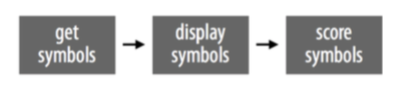

First, `play` generates three symbols (step 1), then it displays them in the console window (astep 2), and then it scores them (step 3):

```r
play <- function() {
  # step 1: generate symbols
  symbols <- get_symbols()
  # step 2: display the symbols
  print(symbols)
  # step 3: score the symbols
  score(symbols)
}
```

To have R execute steps in sequence, place the steps one after another in an R script or function body.

## Parallel Cases

Another way to divide a task is to spot groups of similar cases within the task. Some tasks require different algorithms for different groups of input. If you can identify those groups, you can work out their algorithms one at a time.

For example, score will need to calculate the prize one way if symbols contains three of a kind (In that case, `score` will need to match the common symbol to a prize). `score` will need to calculate the prize a second way if the symbols are all bars (In that case, `score` can just assign a prize of $5). And, finally, `score` will need to calculate the prize in a third way if the symbols do not contain three of a kind or all bars (In that case, score must count the number of cherries present). `score` will never use all three of these algorithms at once; it will always choose just one algorithm to run based on the com‐ bination of symbols.

Diamonds complicate all of this because diamonds can be treated as wild cards. Let’s ignore that for now and focus on the simpler case where diamonds double the prize but are not wilds. `score` can double the prize as necessary after it runs one of the following algorithms, as shown below.

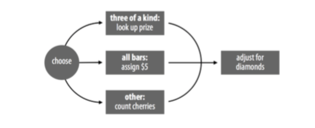

Adding the score cases to the play steps reveals a strategy for the complete slot machine program, as shown below.

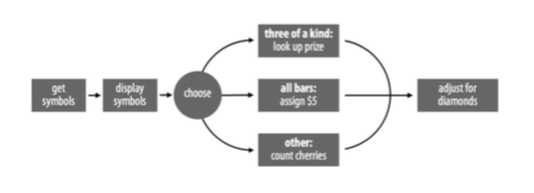

We’ve already solved the first few steps in this strategy. Our program can get three slot machine symbols with the `get_symbols` function. Then it can display the symbols with the `print` function. Now let’s examine how the program can handle the parallel score cases.

## `if` Statements

Linking cases together in parallel requires a bit of structure; your program faces a fork in the road whenever it must choose between cases. You can help the program navigate this fork with an `if` statement.

An `if` statement tells R to do a certain task for a certain case. In English you would say something like, “If this is true, do that.” In R, you would say:

```r
if (this) {
  that
}
```

The this object should be a logical test or an R expression that evaluates to a single `TRUE` or `FALSE`. If this evaluates to `TRUE`, R will run all of the code that appears between the braces that follow the if statement (i.e., between the `{` and `}` symbols). If this evaluates to `FALSE`, R will skip the code between the braces without running it.

For example, you could write an `if` statement that ensures some object, `num`, is positive:

```r
if (num < 0){
  num <- num * -1
}
```

If `num < 0` is `TRUE`, R will multiply num by negative one, which will make `num` positive:

```r
num <- -2
if (num < 0){
  num <- num * -1
}
num
```

```
[1] 2
```

If `num < 0` is `FALSE`, R will do nothing and num will remain as it is—positive (or zero):

```r
num <- 4
if (num < 0){
  num <- num * -1
}
num
```

```
[1] 4
```

The condition of an `if` statement must evaluate to a *single* `TRUE` or `FALSE`. If the condition creates a vector of `TRUE`s and `FALSE`s (which is easier to make than you may think), your `if` statement will print a warning message and use only the first element of the vector. Remember that you can condense vectors of logical values to a single `TRUE` or `FALSE` with the functions `any` and `all`.

You don’t have to limit your if statements to a single line of code; you can include as many lines as you like between the braces. For example, the following code uses many lines to ensure that `num` is positive. The additional lines print some informative statements if `num` begins as a negative number. R will skip the entire code block—print statements and all—if `num` begins as a positive number:

```r
num <- -1
if(num < 0){
  print("num is negative.")
  print("Don't worry, I'll fix it.")
  num <- num * -1
  print("Now num is positive.")
}
```

```
[1] "num is negative."
[1] "Don't worry, I'll fix it."
[1] "Now num is positive."
```

```r
num
```

```
[1] 1
```

## `else` Statements

`if` statements tell R what to do when your condition is true, but you can also tell R what to do when the condition is false. `else` is a counterpart to `if` that extends an `if` statement to include a second case. In English, you would say, “If this is true, do plan A; else do plan B.” In R, you would say:

```r
if (this) {
  Plan A
} else {
  Plan B
}
```

When this evaluates to `TRUE`, R will run the code in the first set of braces, but not the code in the second. When this evaluates to `FALSE`, R will run the code in the second set of braces, but not the first.

```r
a <- pi
a
```

```
[1] 3.141593
```

```r
dec <- a - trunc(a)
if(dec >= 0.5){
  a <- trunc(a) + 1
} else {
  a <- trunc(a)
}
a
```

```
[1] 3
```

If your situation has more than two mutually exclusive cases, you can string multiple `if` and `else` statements together by adding a new `if` statement immediately after `else`. For example:

```r
a <- 1
b <- 1

if(a > b){
  print("A wins!")
} else if (a < b) {
  print("B wins!")
} else {
  print("Tie.")
}
```

```
[1] "Tie."
```

R will work through the if conditions until one evaluates to `TRUE`, then R will ignore any remaining `if` and `else` clauses in the tree. If no conditions evaluate to `TRUE`, R will run the final `else` statement.

If two `if` statements describe mutually exclusive events, it is better to join the `if` statements with an `else if` than to list them separately. This lets R ignore the second `if` statement whenever the first returns a `TRUE`, which saves work.

You can use `if` and `else` to link the subtasks in your slot-machine function. The code will be the skeleton of our final `score` function. Compare it to the flow chart for `score` shown below.

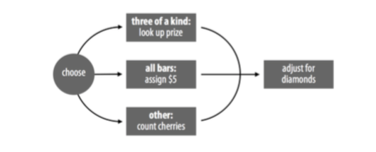

```r
if (# Case 1: all the same #1) {
  prize <- # look up the prize #2
  } else if (# Case 2: all bars #3) {
    prize <- # assign $5 #4
    } else {
      # count cherries #5
      prize <- # calculate a prize #6
    }
# count diamonds #7
# double the prize if necessary #8
```

If you like, you can reorganize your flow chart around these tasks, as shown below. The chart will describe the same strategy, but in a more precise way. I’ll use a diamond shape to symbolize an `if else` decision.

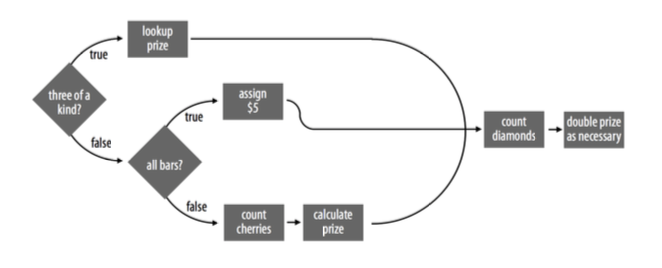

Now we can work through the subtasks one at a time, adding R code to the `if` tree as we go. Each subtask will be easy to solve if you set up a concrete example to work with and try to describe a solution in English before coding in R.

The first subtask asks you to test whether the symbols are three of a kind. How should you begin writing the code for this subtask?

You know that the final score function will look something like this:

```r
score <- function(symbols) {
      # calculate a prize
prize
}
```

Its argument, `symbols`, will be the output of `get_symbols`, a vector that contains three character strings. You could start writing score as I have written it, by defining an object named `score` and then slowly filling in the body of the function. However, this would be a bad idea. The eventual function will have eight separate parts, and it will not work correctly until all of those parts are written (and themselves work correctly). This means you would have to write the entire score function before you could test any of the subtasks. If score doesn’t work—which is very likely—–you will not know which subtask needs fixed.

You can save yourself time and headaches if you focus on one subtask at a time. For each subtask, create a concrete example that you can test your code on. For example, you know that `score` will need to work on a vector named `symbols` that contains three character strings. If you make a real vector named `symbols`, you can run the code for many of your subtasks on the vector as you go:

```r
symbols <- c("7", "7", "7")
```

If a piece of code does not work on `symbols`, you will know that you need to fix it before you move on. You can change the value of `symbols` from subtask to subtask to ensure that your code works in every situation:

```r
symbols <- c("B", "BB", "BBB")
symbols <- c("C", "DD", "0")
```

Only combine your subtasks into a `score` function once each subtask works on a concrete example. If you follow this plan, you will spend more time using your functions and less time trying to figure out why they do not work.

After you set up a concrete example, try to describe how you will do the subtask in English. The more precisely you can describe your solution, the easier it will be to write your R code.

Our first subtask asks us to “test whether the symbols are three of a kind.” This phrase does not suggest any useful R code to me. However, I could describe a more precise test for three of a kind: three symbols will be the same if the first symbol is equal to the second and the second symbol is equal to the third. Or, even more precisely:

*A vector named `symbols` will contain three of the same symbol if the first element of `symbols` is equal to the second element of `symbols` and the second element of `symbols` is equal to the third element of `symbols`.*